# **Libraries import**

# **Analysis of players' sports performance about their age**

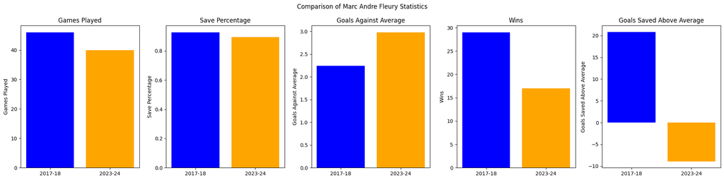

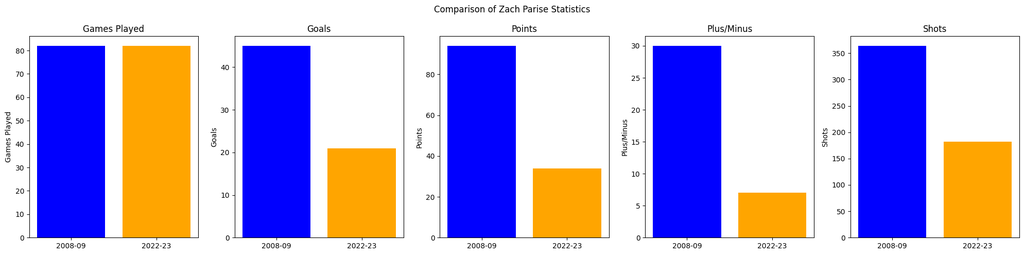

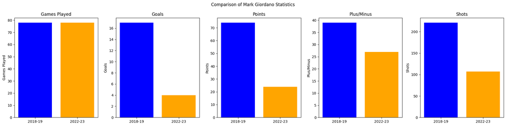

```python
# Function to load data, query, and plot for a player
def plot_player_comparison(csv_url, seasons, stats, stat_titles, title, colors=['blue', 'orange']):
    df = pd.read_csv(csv_url, encoding='ISO-8859-1')

    # Connect to a SQLite database (or create it)
    conn = sqlite3.connect(':memory:')  # Create an in-memory database

    # Load the DataFrame into the SQLite database
    df.to_sql('player_stats', conn, index=False, if_exists='replace')

    # Enclose column names with special characters in double quotes
    stats_quoted = [f'"{stat}"' if any(char in stat for char in ['%', '+', '/']) else stat for stat in stats]

    # Query the data for the specified seasons
    query = f'''
    SELECT Season, {", ".join(stats_quoted)}
    FROM player_stats
    WHERE Season IN ({", ".join(f"'{season}'" for season in seasons)})
    '''

    df_comparison = pd.read_sql_query(query, conn)
    conn.close()

    # Plot the comparison
    num_stats = len(stats)
    fig, ax = plt.subplots(1, num_stats, figsize=(4 * num_stats, 5))

    for i, (stat, stat_title) in enumerate(zip(stats, stat_titles)):
        ax[i].bar(df_comparison['Season'], df_comparison[stat], color=colors)
        ax[i].set_title(stat_title)
        ax[i].set_ylabel(stat_title)

    fig.suptitle(title)
    plt.tight_layout()
    plt.show()

# Fleury
fleury_csv = 'https://github.com/tadeaskaminsky/nhl_analysis/raw/main/Fleury.csv'
fleury_seasons = ['2017-18', '2023-24']
fleury_stats = ['GP', 'SV%', 'GAA', 'W', 'GSAA']
fleury_stat_titles = ['Games Played', 'Save Percentage', 'Goals Against Average', 'Wins', 'Goals Saved Above Average']
plot_player_comparison(fleury_csv, fleury_seasons, fleury_stats, fleury_stat_titles, 'Comparison of Marc Andre Fleury Statistics')

# Parise
parise_csv = 'https://github.com/tadeaskaminsky/nhl_analysis/raw/main/Parise.csv'
parise_seasons = ['2008-09', '2022-23']
parise_stats = ['GP', 'G', 'PTS', '+/-', 'S']
parise_stat_titles = ['Games Played', 'Goals', 'Points', 'Plus/Minus', 'Shots']
plot_player_comparison(parise_csv, parise_seasons, parise_stats, parise_stat_titles, 'Comparison of Zach Parise Statistics')

# Giordano
giordano_csv = 'https://github.com/tadeaskaminsky/nhl_analysis/raw/main/Giordano.csv'
giordano_seasons = ['2018-19', '2022-23']
giordano_stats = ['GP', 'G', 'PTS', '+/-', 'S']
giordano_stat_titles = ['Games Played', 'Goals', 'Points', 'Plus/Minus', 'Shots']
plot_player_comparison(giordano_csv, giordano_seasons, giordano_stats, giordano_stat_titles, 'Comparison of Mark Giordano Statistics')
```

## **Conclusion**

Our analysis was conducted with the utmost objectivity, aiming to show whether the age of hockey players has an impact on their performance, and the extent of this impact. We compared a season from a younger period of their lives with one of the most recent seasons played, ensuring a fair and objective comparison by selecting seasons with a similar number of games. We chose three players from different positions on the ice: Marc-André Fleury (goalie), Zach Parise (left-wing or forward), and Mark Giordano (defenseman). The results are clear and unbiased, showing a significant deterioration in performance for each player, indicating that age is indeed having a significant negative impact on their on-ice performance.

- Explanation of some terms:
1. Save percentage - expresses the percentage of shot attempts that the number of shots on goal taken by the goalkeeper as a proportion of the total number of shots on goal.
2. Plus/Minus - If a player is on the ice when his team scores a goal when the game is tied, the player receives a +1 point. Conversely, if a player is on the ice when the opposing team scores a goal when the game is tied, the player receives -1 point.
3. Goals Saved Above Average - If a goalie has a positive GSAA, he has saved more goals than the average goalie would have saved. Conversely, if the GSAA is negative, he has saved fewer goals than the average goalkeeper.